# Stats For Chapter 2

2025-02-27

## Introduction

In this study, I compared the performance of the control (standard multiclass classification) approach to 4 possible OSR models on increasingly open test data with 3 conditions: all, some, and target. I have trained and tested a model for each of these model type x condition scenarios. Here, I evaluate the following hypotheses using the collated performance scores:

1. Control models would exhibit significantly lower performance when tested on open compared to closed data.
2. All multiclass models (control, other, threshold) would exhibit significantly lower performance when tested on open compared to closed data, while divide-and-conquer strategies (one-class and binary) would not differ.
3. Combined predictions from multiple binary one-vs-all models would achieve the highest performance of all models tested on open data in conditions some and target.

## Evaluation Metrics

For these evaluations, I use three key metrics: - Accuracy - F1 score (harmonic mean of precision and recall)  
- Youden’s J statistic (referred to as Open Set F score)

To account for differing numbers of classes between models, I compare observed predictions to chance predictions from a naive random guesser. For n classes, the chance levels are: - Random accuracy = 1/n - Random F1 = 1/n  
- Random Youden’s J = 2/n - 1

I use weighted averages across all behaviors (target and non-target) to provide balanced comparisons between models.

## Hypothesis 1: Effect of Open Set on Control Performance

I hypothesised that the control model would decline in performance when tested on open rather than closed sets. To test this, I isolated my results from my control models.

I plotted this relationship where the coral line is the performance of chance for each metric.

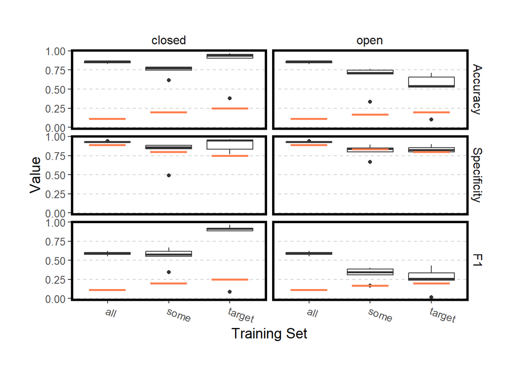

Now I tested the hypothesis using a subset of the data where model is control. First I identified the best explanatory model.

```
##    df        AIC
## m1  9   9.889489
## m2  8 -10.079219
## m3  7 -11.503295
## m4  5  -5.159175
```

```
##    df       AIC
## m1  9 22.500266
## m2  8  1.130360
## m3  7 -1.694913
## m4  5  1.846812
```

```
## Data: control_df
## Models:
## m4: F1 ~ closed_open + training_set, zi=~0, disp=~1
## m3: F1 ~ closed_open * training_set, zi=~0, disp=~1
##    Df      AIC     BIC  logLik deviance  Chisq Chi Df Pr(>Chisq)
## m4  5  -5.1592  1.8468  7.5796  -15.159
## m3  7 -11.5033 -1.6949 12.7516  -25.503 10.344      2   0.005673 **
## ---
## Signif. codes:  0 '***' 0.001 '**' 0.01 '*' 0.05 '.' 0.1 ' ' 1
```

```
## qu = 0.75, log(sigma) = -3.28982 : outer Newton did not converge fully.
```

```
## qu = 0.75, log(sigma) = -3.331946 : outer Newton did not converge fully.
```

```
## qu = 0.75, log(sigma) = -3.313437 : outer Newton did not converge fully.
```

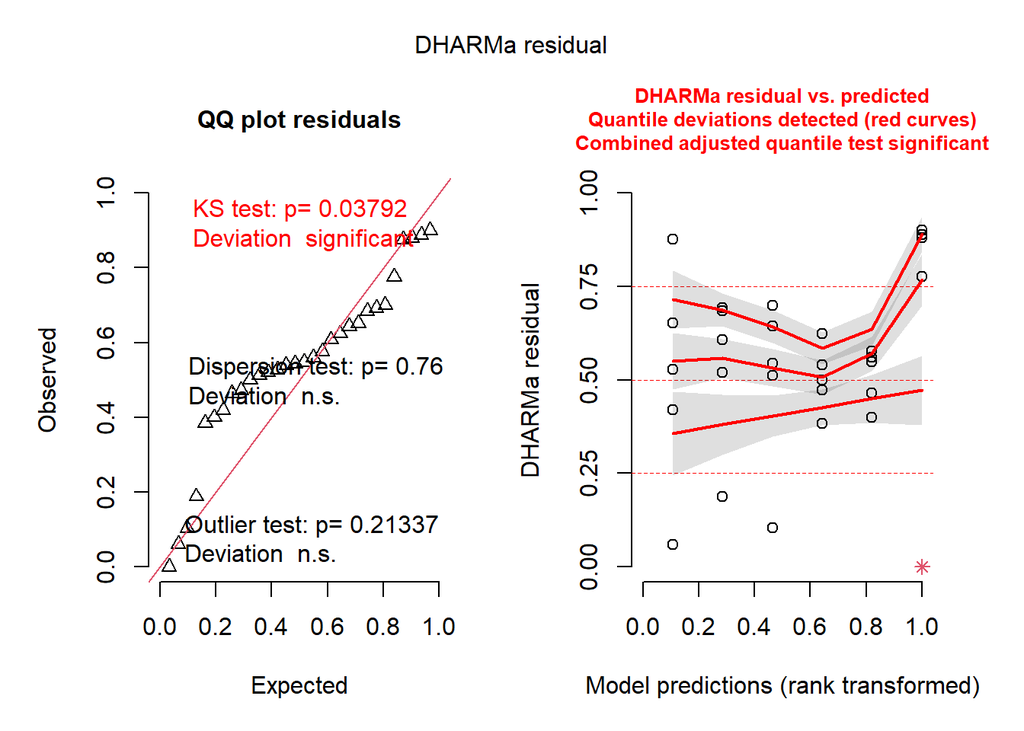

m3 was found to be the most explanatory variable but assumptions were not met… Pause here… Not sure what to do.

## Hypothesis 2: Performance Patterns Across Model Types

I hypothesised that the three multiclass models (control, threshold, and other) would all significantly degrade in performance between the all and reduced training conditions whereas the divide and conquer methods would not.

Firstly I plotted this data.

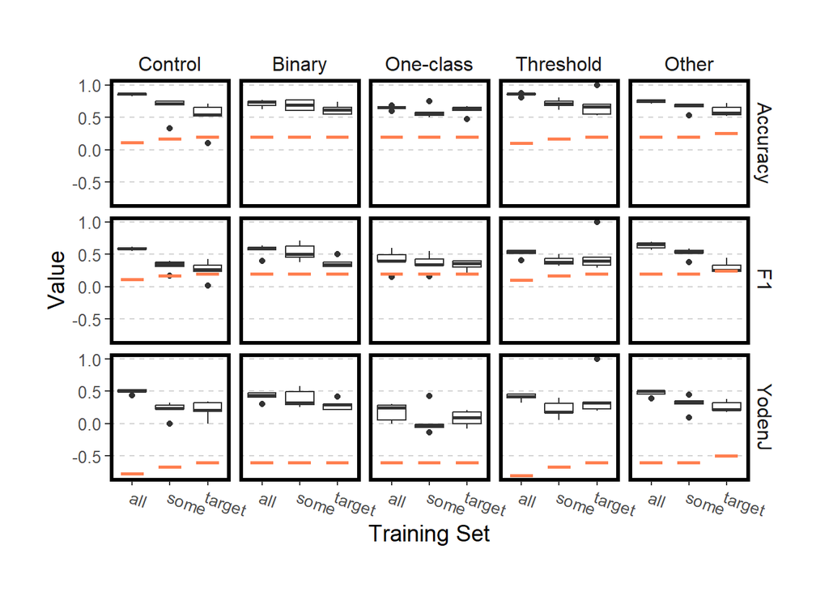

An alternative way to look at this same data is:

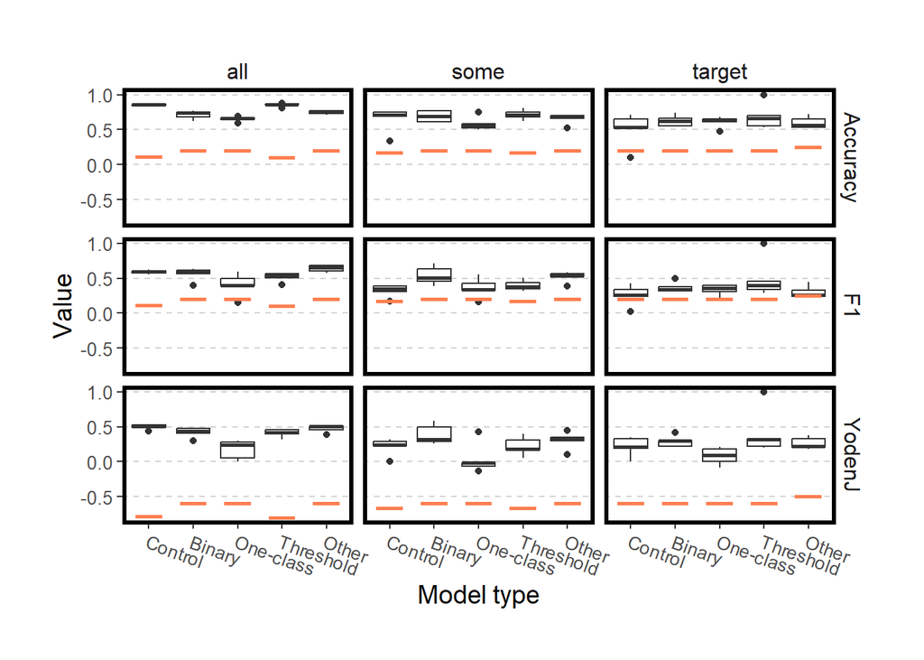

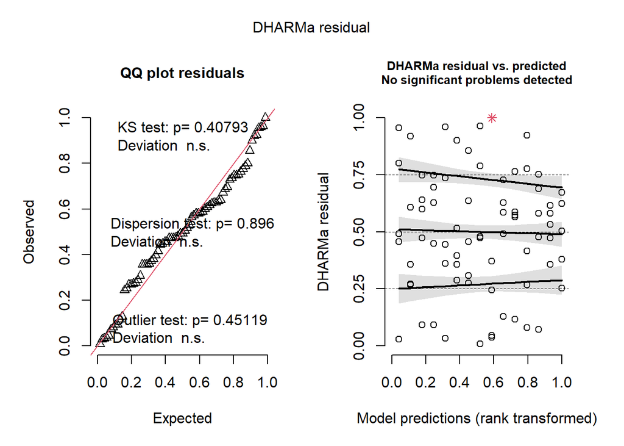

It met assumptions, so I can analyse it.

```
##            R2m       R2c
## [1,] 0.5152819 0.5152819
```

```
##  Family: gaussian  ( identity )
## Formula:          F1 ~ model_type * training_set + (1 | fold)
## Data: open_df
##
##      AIC      BIC   logLik deviance df.resid
##    -82.8    -43.4     58.4   -116.8       58
##
## Random effects:
##
## Conditional model:
##  Groups   Name        Variance  Std.Dev.
##  fold     (Intercept) 3.179e-12 1.783e-06
##  Residual             1.234e-02 1.111e-01
## Number of obs: 75, groups:  fold, 5
##
## Dispersion estimate for gaussian family (sigma^2): 0.0123
##
## Conditional model:
##                                         Estimate Std. Error z value Pr(>|z|)
## (Intercept)                             0.588837   0.049682  11.852  < 2e-16
## model_typeBinary                       -0.027704   0.070262  -0.394 0.693356
## model_typeOne-class                    -0.181111   0.070262  -2.578 0.009947
## model_typeThreshold                    -0.071519   0.070262  -1.018 0.308728
## model_typeOther                         0.051680   0.070262   0.736 0.462011
## training_setsome                       -0.267124   0.070262  -3.802 0.000144
## training_settarget                     -0.332074   0.070262  -4.726 2.29e-06
## model_typeBinary:training_setsome       0.243775   0.099365   2.453 0.014154
## model_typeOne-class:training_setsome    0.221230   0.099365   2.226 0.025985
## model_typeThreshold:training_setsome    0.148471   0.099365   1.494 0.135123
## model_typeOther:training_setsome        0.144217   0.099365   1.451 0.146672
## model_typeBinary:training_settarget     0.137372   0.099365   1.383 0.166817
## model_typeOne-class:training_settarget  0.256207   0.099365   2.578 0.009925
## model_typeThreshold:training_settarget  0.311197   0.099365   3.132 0.001737
## model_typeOther:training_settarget     -0.005783   0.099365  -0.058 0.953589
##
## (Intercept)                            ***
## model_typeBinary
## model_typeOne-class                    **
## model_typeThreshold
## model_typeOther
## training_setsome                       ***
## training_settarget                     ***
## model_typeBinary:training_setsome      *
## model_typeOne-class:training_setsome   *
## model_typeThreshold:training_setsome
## model_typeOther:training_setsome
## model_typeBinary:training_settarget
## model_typeOne-class:training_settarget **
## model_typeThreshold:training_settarget **
## model_typeOther:training_settarget
## ---
## Signif. codes:  0 '***' 0.001 '**' 0.01 '*' 0.05 '.' 0.1 ' ' 1
```

Fold provided very little variance. F1, ‘One-class’ performed significantly worse than the control, but no other models did. I found that target and some performed significantly worse than all. For the interactions: - Binary and one-class significantly better than control in ‘some’ - Threshold and one-class significantly better than control in ‘target’

```
##            R2m       R2c
## [1,] 0.5256143 0.5271123
```

```
##  Family: gaussian  ( identity )
## Formula:          YodenJ ~ model_type * training_set + (1 | fold)
## Data: open_df
##
##      AIC      BIC   logLik deviance df.resid
##    -60.8    -21.4     47.4    -94.8       58
##
## Random effects:
##
## Conditional model:
##  Groups   Name        Variance  Std.Dev.
##  fold     (Intercept) 5.226e-05 0.007229
##  Residual             1.650e-02 0.128439
## Number of obs: 75, groups:  fold, 5
##
## Dispersion estimate for gaussian family (sigma^2): 0.0165
##
## Conditional model:
##                                        Estimate Std. Error z value Pr(>|z|)
## (Intercept)                             0.49872    0.05753   8.669  < 2e-16 ***
## model_typeBinary                       -0.07821    0.08123  -0.963 0.335667
## model_typeOne-class                    -0.32189    0.08123  -3.963 7.41e-05 ***
## model_typeThreshold                    -0.08707    0.08123  -1.072 0.283756
## model_typeOther                        -0.02356    0.08123  -0.290 0.771768
## training_setsome                       -0.28333    0.08123  -3.488 0.000487 ***
## training_settarget                     -0.28482    0.08123  -3.506 0.000454 ***
## model_typeBinary:training_setsome       0.25237    0.11488   2.197 0.028033 *
## model_typeOne-class:training_setsome    0.14567    0.11488   1.268 0.204797
## model_typeThreshold:training_setsome    0.09413    0.11488   0.819 0.412578
## model_typeOther:training_setsome        0.11527    0.11488   1.003 0.315677
## model_typeBinary:training_settarget     0.15527    0.11488   1.352 0.176494
## model_typeOne-class:training_settarget  0.18867    0.11488   1.642 0.100514
## model_typeThreshold:training_settarget  0.28808    0.11488   2.508 0.012153 *
## model_typeOther:training_settarget      0.07234    0.11488   0.630 0.528897
## ---
## Signif. codes:  0 '***' 0.001 '**' 0.01 '*' 0.05 '.' 0.1 ' ' 1
```

### More detail about the significant models

For the models that suggested better weighted average than control performance, I looked at individual behaviours. First I looked at Threshold.

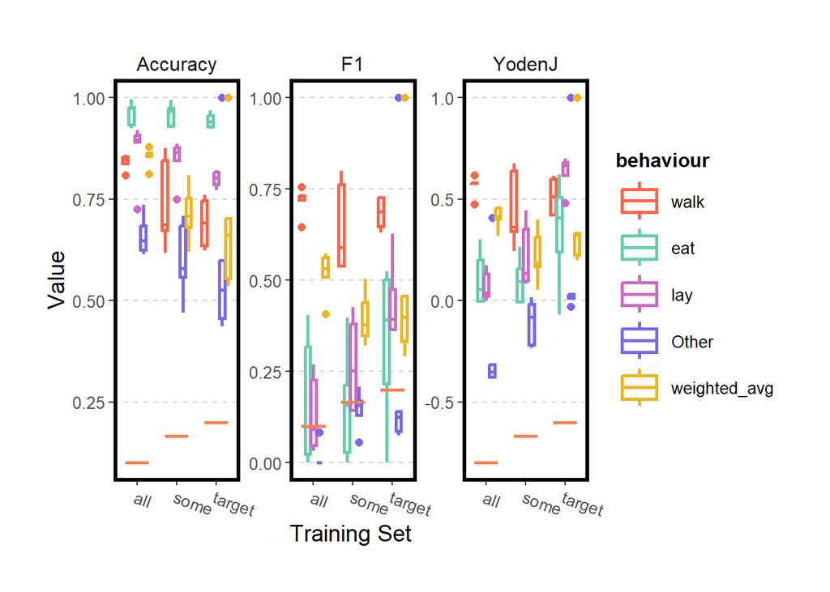

I looked more closely into the ‘Binary’ model, plotting all of the individual behaviours to see why this result was the case for the F1 score.

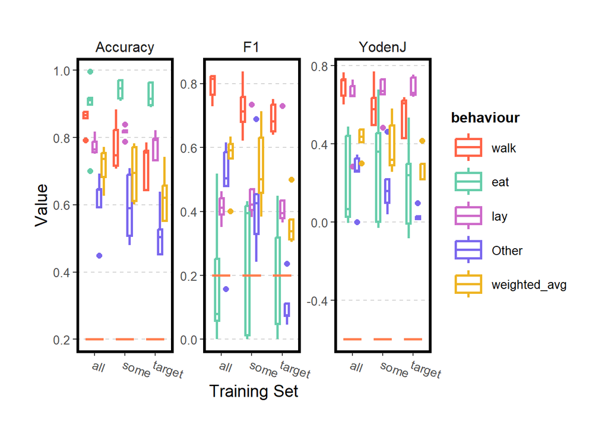